# Símptomes vocals dels professors

Pregunta 1: Els professors donen manco importància a la veu que a l’esport o l’alimentació?

Autor/a

Miquel Àngel Aguiló, Joan Camps, Gerard Ribas

Publicat

18 d’octubre de 2024

Enllaç [git](https://github.com/gerardet46/Entrega_2_AD).

### Introducció

L’objectiu d’aquest informe és contestar la pregunta *“Els professors donen menys importància a la veu que a l’esport o a l’alimentació?”*. El conjunt de dades s’ha obtingut a partir d’una enquesta que estudia la salut vocal contestada per una mostra de professors. Per contestar la pregunta, estudiarem les respostes a les preguntes *“Quina importància dona al …?”*, puntuades de l’1 al 10, per poder comparar la importància que es dona a cadascun dels factors.

A més, hem netejat les dades per tenir noms de variables més manejables i hem calculat el *VHI*, com a la suma de puntuacions de les preguntes amb resposta des de *Mai* a *Sempre*, del 0 al 4, respectivament. Recordem que una major *VHI* implica una menor qualitat de veu.

### Anàlisi exploratòria

Inicialment creuarem les dades d’importància a la veu amb importància a l’alimentació; i d’importància a la veu amb importància a l’esport.

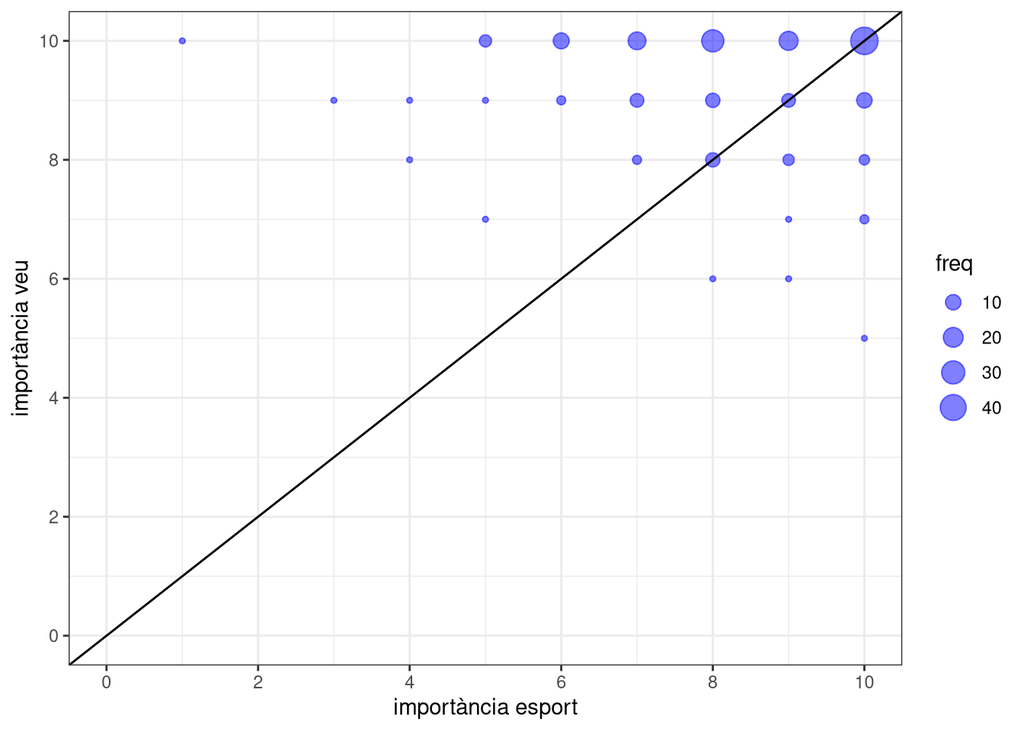

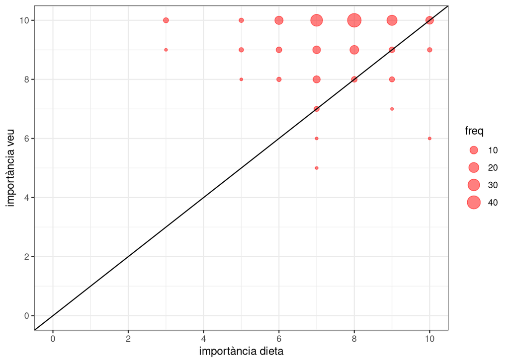

La recta diagonal del gràfic indica la resposta de donar la mateixa importància als dos factors. Si s’està per damunt, es dona més importància a la veu, i de fet veim que aquest és el cas més freqüent. De fet, en el cas de l’alimentació la importància a la veu envers de l’alimentació és més marcada. Notem també que en general la importància donada a les respostes és alta.

Vegem si hi ha cap relació lineal entre les variables d’interès.

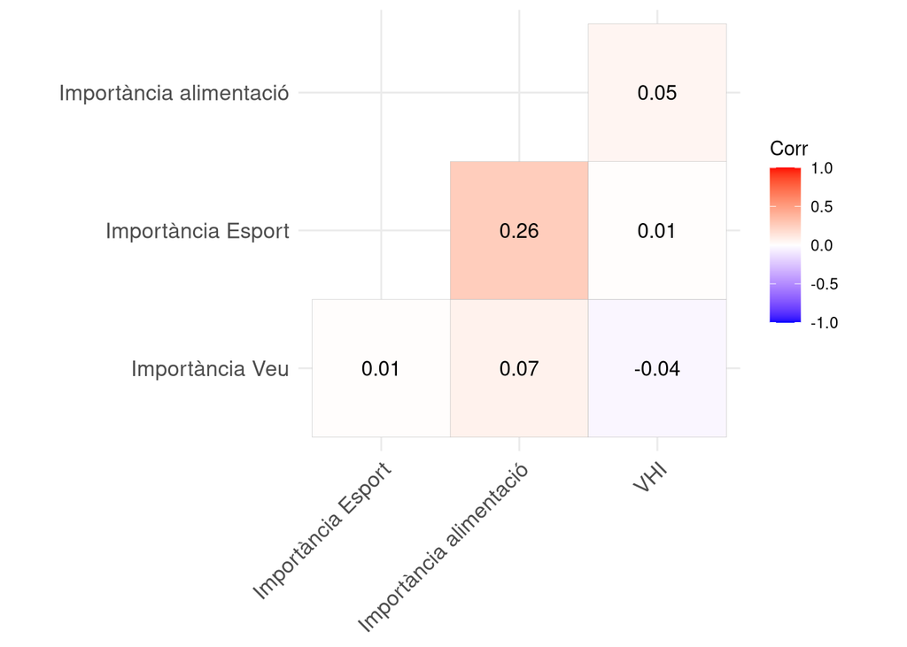

Veim que la importància a l’esport i l’alimentació amb la veu no estan gens correlacionades. És més, tampoc no es veu una correlació entre la importància a la veu i la VHI, però el valor obtingut és negatiu, com s’espera.

Anem a veure també la distribució de les respostes, així com alguns estadístics.

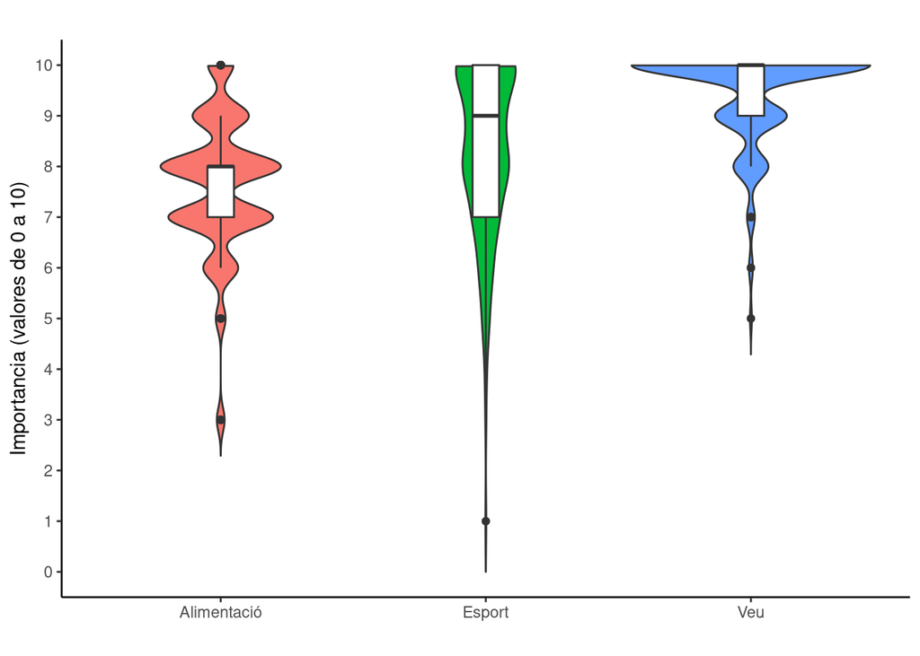

Analitzant el gràfic, podem veure que les tendències de les respostes segueixen un ordre. Les respostes a la veu solen ser més altes que a esport, i aquestes darreres a alimentació. Així, les medianes a cada variable també segueixen aquest ordre.

### Inferència

Intuïtivament podem pensar que sí hi ha interacció entre blocs i tractaments: la diferència entre importància donada a alimentació i veu pot variar molt entre els individus. Procedim amb el test:

```
    Friedman rank sum test

data:  nota and Tractament and id
Friedman chi-squared = 158.43, df = 2, p-value < 2.2e-16
```

El p-valor és ínfim, i concloem que en mediana no es dona la mateixa importància a esport, veu i alimentació. Ara, ens interessa saber quines parelles de blocs tenen una diferència significativa en les medianes.

```
    Pairwise comparisons using Wilcoxon signed rank test with continuity correction

data:  df_anova$nota and df_anova$Tractament

                    dieta_saludable importancia_deporte
importancia_deporte 3.0e-07         -
importancia_voz     < 2e-16         1.1e-12

P value adjustment method: holm
```

Per tant, en mitjana es dona una importància diferent a cada un dels tres aspectes. Responent l’objectiu plantejat, concloem que els professors donen més importància a la veu que a l’esport o a l’alimentació.

# Proposta de resposta global

La idea és contestar la pregunta de *“la formació en veu afecta a la seva percepció de qualitat?”*. A partir de les dades recollides, proposam fixar-nos en les respostes a *“Té formació sobre salut vocal?”* i fer tres grups:

- Fora formació
- Formació independent (respostes a *“vaig fer un curs fa temps”* i *“he fet un curs pel meu compte”*)
- Formació concreta (respostes a *“logopeda”* i *“curs de servei de precaució”*)

Llavors, mostrar en un gràfic de violí les densitats de la VHI a cada grup, i fer una ANOVA d’una via amb les poblacions.

Cap a dir que les respostes al qüestionari semblen incoherents en ocasions. Centrant-nos en les variables tractades en aquesta pregunta, les tendències a la importància donada a veu, esport i alimentació són pràcticament sempre molt altes. De fet, la densitat de la resposta a la importància a la veu sembla estar condicionada pel fet de respondre un qüestionari sobre el propi tema. Proposam valorar les importàncies donades als factors en base a criteris objectius preestablerts per aconseguir una representació més fidel. Per exemple, hi ha individus responent amb molta importància a l’esport que realitzen manco esport a individus que n’hi donen molt poca; o individus que consumeixen alcohol, gasosa i cafès habitualment que donen molta importància a la dieta.

## Implementació de la proposta

```r
# obtenim les distintes respostes a "formacion_voz"
data %>% select(formacion_voz) %>% distinct
```

```
                                                                              formacion_voz
1                                                             Si, vaig fer un curs fa temps
2                                                               No, mai he fet cap formació
3                               He hagut de fer sessions de rehabilitació vocal (logopèdia)
4                                                      He fet formació vocal pel meu compte
5           He fet la formació Com puc cuidar la meva veu impartida pel Servei de Prevenció
6                                                                          Si tenc Formació
7                                                                 He fet algun curs de cant
8                Aquest curs farem la formació de la veu impartida pel Servei de Prevenció
9 He fet sessions amb logopeda fa anys j el curs de com puc cuidar la meva veu l'any passat
```

```r
# agrupam les formacions
# Independent       -> un curs fa temps, formació pel meu compte, curs de cant, Si tenc formació
# Formació concreta -> logopèdia, la formació que imparteixen ells
# Sense formació    -> mai, aquest any farem la formació
data <- data %>% mutate(formacion = case_when(
     str_detect(formacion_voz, "un curs fa temps|meu compte|algun curs de cant|Si tenc Formació") ~ "Formació independent",
     str_detect(formacion_voz, "logop|He fet la formac") ~ "Formació concreta",
     TRUE ~ "Sense formació"
   ), .after = formacion_voz)

# número de mostres de cada grup
data %>% select(formacion) %>% table
```

```
formacion
   Formació concreta Formació independent       Sense formació
                  54                   32                   99
```

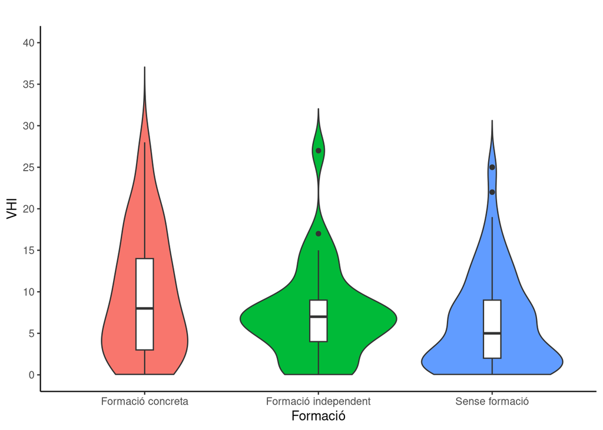

```r
# gràfic de violí
ggplot(data, aes(x=formacion, y=VHI, fill=formacion)) +
  geom_violin(trim=FALSE)+
  geom_boxplot(width=0.1, fill="white")+
  labs(title="",x="Formació", y = "VHI") +
  theme_classic() +
  theme(
    legend.position="none",
    plot.title = element_text(size=11)
  ) +
  scale_y_continuous(limits=c(0,40),breaks = seq(0, 40, 5))
```

```r
# normalitat
data %>% subset(formacion == "Formació independent") %>% select(VHI) %>% as_vector %>% shapiro.test
```

```
    Shapiro-Wilk normality test

data:  .
W = 0.89152, p-value = 0.003794
```

```r
# ja hi ha un bloc que no és normal
# Per tant, hem de fer un ANOVA no paramètric
kruskal.test(VHI~formacion, data = data)
```

```
    Kruskal-Wallis rank sum test

data:  VHI by formacion
Kruskal-Wallis chi-squared = 8.5973, df = 2, p-value = 0.01359
```

```r
# Concloem que, amb una significància de 0.05, sí hi ha diferències en les medianes.
# Per tant, facem el test per parelles per veure quines són diferents.
pairwise.wilcox.test(data$VHI, data$formacion, p.adjust.method = 'bonferroni')
```

```
    Pairwise comparisons using Wilcoxon rank sum test with continuity correction

data:  data$VHI and data$formacion

                     Formació concreta Formació independent
Formació independent 0.713             -
Sense formació       0.012             0.664

P value adjustment method: bonferroni
```

```r
# Obtenim que l'única parella amb medianes significativament diferents és la de formació concreta-sense formació.
# Tot i això, els que no tenen formació tenen menor VHI que els que sí en tenen
```